# Homework Assignment 1

Beatriz Wahle

### HW-1 Instructions

> Our class emphasizes clear communication of data analysis results to non-technical audiences. I expect your HTML output documents to be readable and well formatted. I expect you to put ample comments in your R code to make the code understandable. Along with accuracy of results, I am looking for quality of presentation as well. To complete this assignment, follow these steps:
1. Download the `HW1.Rmd` file from Canvas.
2. Open `HW1.Rmd` in RStudio.
3. Replace the “Your Name Here” text in the `author:` field with names of the students in HW team.
4. Supply your solutions to the homework by editing `HW1.Rmd`.
5. When you have completed the homework and have **checked** that your code both runs in the Console and knits correctly when you click `Knit HTML`, rename the R Markdown file to `HW1_YourNamesHere.Rmd` and then knit again. Submit both the RMD and HTML file on Canvas. (Obv: YourNameHere should be changed to your own name).
6. Run your code in the Console and Knit HTML frequently to check for errors.
7. You may find it easier to solve a problem by interacting only with the Console at first.

We will continue working with the nycflights13 dataset we looked at last class.

First - lets read the data into an object named `nyc`.

```r
# Please install the nycflights13 package in your console first
library(nycflights13)
nyc <- nycflights13::flights
```

Libraries

```r
library(dplyr)
```

I now would like you to answer the following - all in their own separate R code blocks.

### Data Exploration

Let’s first do some simple exploration of this data. I would like for you to answer each of the questions below with an **inline R code** integrated into the text and not in a separate R code block.

- How many airlines are there? (Hint: `levels` and `length` can be useful here)

There are 16 airlines in the dataset. There are 16 airlines in the dataset.

- How many flights there were by the airline with code `OO`? (Hint: `nrow` can be useful here along with logical indexing)

There were 32 flights by the airline with code `OO`.

- How long is the shortest flight out of any NYC airport? (Hint: `min` can be useful, remember to handle `NA` values)

The shortest flight out of NYC is 20 minutes.

- How many flights where there by United Airlines (code: UA) on Jan 12th 2013?

There were 112 flight

There were 119 flight

(The second filters wrongly some flights from the 11th and misses some of the 12th and I dont understand why! Ask teacher )

### Basics First

You would want to run `str` and `summary` commands and take a look at the output to make sure you have a good understanding of the datatset. Let’s answer a few basic questions first.

```r
str(nyc)
```

```
## tibble [336,776 × 19] (S3: tbl_df/tbl/data.frame)
##  $ year          : int [1:336776] 2013 2013 2013 2013 2013 2013 2013 2013 2013 2013 ...
##  $ month         : int [1:336776] 1 1 1 1 1 1 1 1 1 1 ...
##  $ day           : int [1:336776] 1 1 1 1 1 1 1 1 1 1 ...
##  $ dep_time      : int [1:336776] 517 533 542 544 554 554 555 557 557 558 ...
##  $ sched_dep_time: int [1:336776] 515 529 540 545 600 558 600 600 600 600 ...
##  $ dep_delay     : num [1:336776] 2 4 2 -1 -6 -4 -5 -3 -3 -2 ...
##  $ arr_time      : int [1:336776] 830 850 923 1004 812 740 913 709 838 753 ...
##  $ sched_arr_time: int [1:336776] 819 830 850 1022 837 728 854 723 846 745 ...
##  $ arr_delay     : num [1:336776] 11 20 33 -18 -25 12 19 -14 -8 8 ...
##  $ carrier       : chr [1:336776] "UA" "UA" "AA" "B6" ...
##  $ flight        : int [1:336776] 1545 1714 1141 725 461 1696 507 5708 79 301 ...
##  $ tailnum       : chr [1:336776] "N14228" "N24211" "N619AA" "N804JB" ...
##  $ origin        : chr [1:336776] "EWR" "LGA" "JFK" "JFK" ...
##  $ dest          : chr [1:336776] "IAH" "IAH" "MIA" "BQN" ...
##  $ air_time      : num [1:336776] 227 227 160 183 116 150 158 53 140 138 ...
##  $ distance      : num [1:336776] 1400 1416 1089 1576 762 ...
##  $ hour          : num [1:336776] 5 5 5 5 6 5 6 6 6 6 ...
##  $ minute        : num [1:336776] 15 29 40 45 0 58 0 0 0 0 ...
##  $ time_hour     : POSIXct[1:336776], format: "2013-01-01 05:00:00" "2013-01-01 05:00:00" ...
```

```r
summary(nyc)
```

```
##       year          month             day           dep_time    sched_dep_time
##  Min.   :2013   Min.   : 1.000   Min.   : 1.00   Min.   :   1   Min.   : 106
##  1st Qu.:2013   1st Qu.: 4.000   1st Qu.: 8.00   1st Qu.: 907   1st Qu.: 906
##  Median :2013   Median : 7.000   Median :16.00   Median :1401   Median :1359
##  Mean   :2013   Mean   : 6.549   Mean   :15.71   Mean   :1349   Mean   :1344
##  3rd Qu.:2013   3rd Qu.:10.000   3rd Qu.:23.00   3rd Qu.:1744   3rd Qu.:1729
##  Max.   :2013   Max.   :12.000   Max.   :31.00   Max.   :2400   Max.   :2359
##                                                  NA's   :8255
##    dep_delay          arr_time    sched_arr_time   arr_delay
##  Min.   : -43.00   Min.   :   1   Min.   :   1   Min.   : -86.000
##  1st Qu.:  -5.00   1st Qu.:1104   1st Qu.:1124   1st Qu.: -17.000
##  Median :  -2.00   Median :1535   Median :1556   Median :  -5.000
##  Mean   :  12.64   Mean   :1502   Mean   :1536   Mean   :   6.895
##  3rd Qu.:  11.00   3rd Qu.:1940   3rd Qu.:1945   3rd Qu.:  14.000
##  Max.   :1301.00   Max.   :2400   Max.   :2359   Max.   :1272.000
##  NA's   :8255      NA's   :8713                  NA's   :9430
##    carrier              flight       tailnum             origin
##  Length:336776      Min.   :   1   Length:336776      Length:336776
##  Class :character   1st Qu.: 553   Class :character   Class :character
##  Mode  :character   Median :1496   Mode  :character   Mode  :character
##                     Mean   :1972
##                     3rd Qu.:3465
##                     Max.   :8500
##
##      dest              air_time        distance         hour
##  Length:336776      Min.   : 20.0   Min.   :  17   Min.   : 1.00
##  Class :character   1st Qu.: 82.0   1st Qu.: 502   1st Qu.: 9.00
##  Mode  :character   Median :129.0   Median : 872   Median :13.00
##                     Mean   :150.7   Mean   :1040   Mean   :13.18
##                     3rd Qu.:192.0   3rd Qu.:1389   3rd Qu.:17.00
##                     Max.   :695.0   Max.   :4983   Max.   :23.00
##                     NA's   :9430
##      minute        time_hour
##  Min.   : 0.00   Min.   :2013-01-01 05:00:00.00
##  1st Qu.: 8.00   1st Qu.:2013-04-04 13:00:00.00
##  Median :29.00   Median :2013-07-03 10:00:00.00
##  Mean   :26.23   Mean   :2013-07-03 05:22:54.64
##  3rd Qu.:44.00   3rd Qu.:2013-10-01 07:00:00.00
##  Max.   :59.00   Max.   :2013-12-31 23:00:00.00
##
```

- How many destinations can you fly to?

You can fly to 105 different destinations

You can fly to 105 different destinations

- How many flights there were?

There are 3844 different flight, but if you are asking for the total number of flights, there were 336776.

- How many airlines are there?

There are 16 airlines.

- What is the average distance flown?

The average distance flown is 1039.9126036

- What is the median flight time?

The median flight time was 129

- What is the maximum arrival delay?

The maximum arrival delay was 1272

### Data Cleaning

Let’s do some basic data cleaning.

- Delete the columns that are not not needed or superfluous.

```r
nyc$year <- NULL
nyc$hour <- NULL
nyc$minute <- NULL
```

- Factorize the columns that should be treated as a factor but is not currently classified as a factor. (Hint: use the `as.factor` command)

```r
nyc$carrier <- as.factor(nyc$carrier)
nyc$flight <- as.factor(nyc$flight)
nyc$tailnum <- as.factor(nyc$tailnum)
nyc$origin <- as.factor(nyc$origin)
nyc$dest <- as.factor(nyc$dest)
```

- Replace the `NA` values in columns with numerical values with either the mean or the median of that column. Provide explanation for why you used mean or median for replacing `NA` values. (Hint: this will need you to use an ifelse statement. See example below)

```r
#Example code for replacing NA values
nyc$arr_delay <- ifelse(is.na(nyc$arr_delay), median(nyc$arr_delay, na.rm = TRUE), nyc$arr_delay)
nyc$dep_delay <- ifelse(is.na(nyc$dep_delay), median(nyc$dep_delay, na.rm = TRUE), nyc$dep_delay)
nyc$air_time <- ifelse(is.na(nyc$air_time), median(nyc$air_time, na.rm = TRUE), nyc$air_time)
nyc$distance <- ifelse(is.na(nyc$distance), median(nyc$distance, na.rm = TRUE), nyc$distance)

# For all of them I opted to use the median in order to respect the distribution of the data.
# Means can be heavily impacted by outliers, which are possible in all of the columns above
```

### Arrival Delay

Lets focus on Arrival Delay.

- What was the average arrival delay for all airports and all airlines combined in Jan 2013?

The average arrival delay in Jan 2013 was 5.8802029.

The average arrival delay in Jan 2013 was 5.8802029.

- Whats was the median arrival delay for all airports and all airlines combined in Jan 2013?

The average arrival delay in Jan 2013 was -4.

The average arrival delay in Jan 2013 was -4.

Based on your answers to the two questions above, what can you say about the distribution of arrival delays? Provide your answer in a text paragraph form.

From the differences between the median and the mean we can see the influence of outliers on the dataset. The median being -4 indicates that at least 50% of the flights arrive 4 (minutes?) before time, however there are some flights that might delay a lot from time to time, and those pull the mean up to a delay of 5.8, giving the impression most flights are at least a little late when that`s not necessarily true.

### Airline Performance

Lets see if all airlines are equally terrible as far as flight arrival delays are concerned. For this question you will have to make sure that airline column is coded as a factor.

- Calculate average arrival delays by airline (Hint: look up the command `tapply`)

```r
avr_arrival <- tapply(nyc$arr_delay, nyc$carrier, mean, na.rm = TRUE)
avr_arrival
```

```
##         9E         AA         AS         B6         DL         EV         F9
##  6.5977248  0.2361209 -9.8963585  9.3029011  1.5819164 14.6198106 21.7635036
##         FL         HA         MQ         OO         UA         US         VX
## 19.4610429 -6.9152047  9.9620033 10.3437500  3.4291997  1.8848364  1.7041844
##         WN         YV
##  9.3734420 13.6073211
```

- Draw a Bar Plot of Average Arrival Delays for all the Airlines (Hint: command for making a Bar Plot is simply `barplot`)

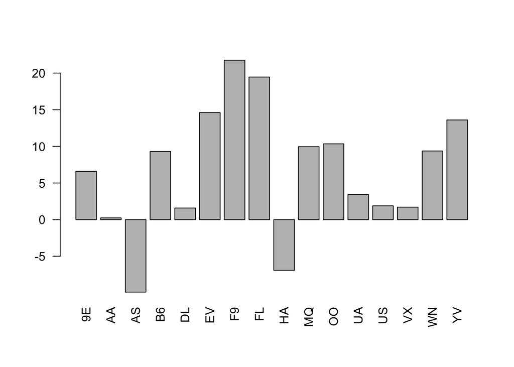

```r
barplot(avr_arrival, las = 2)
```

### Air Gain

Create a new column named `airgain` such that airgain = (departure delay - arrival delay) : this is the amount of delay a flight made up while in air. (Hint: see below for how to create a new column called Z which is X minus Y)

```r
nyc$airgain <- nyc$dep_delay - nyc$arr_delay
str(nyc$airgain)
```

```
##  num [1:336776] -9 -16 -31 17 19 -16 -24 11 5 -10 ...
```

```r
summary(nyc$airgain)
```

```
##     Min.  1st Qu.   Median     Mean  3rd Qu.     Max.
## -196.000   -3.000    7.000    5.718   16.000  639.000
```

Explore airgain data - calculate suitable descriptive statistics and appropriate graphics to better understand this data. This part is open ended - you do what you feel works best for you.

Answer the questions:

- do airlines actually gain any time when in air on average?

```r
mean(nyc$airgain, na.rm = TRUE)
```

```
## [1] 5.717943
```

Yes, in general airlines gain time on air to make up for eventual delays.

- Calculate average airgain for different airlines - which airlines do a better job, which do a worse job?

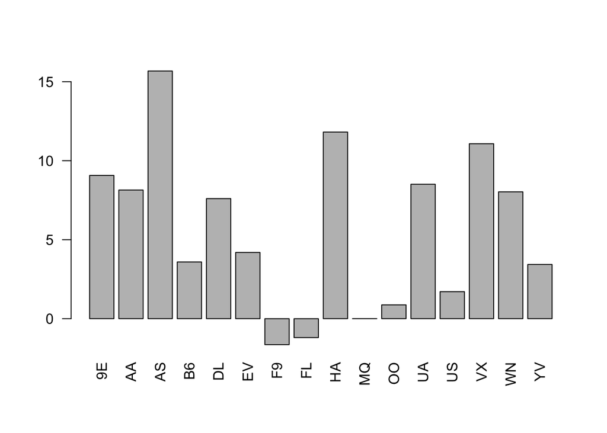

```r
airgain_per_airline <- tapply(nyc$airgain, nyc$carrier, mean, na.rm = TRUE)
airgain_per_airline_median <- tapply(nyc$airgain, nyc$carrier, median, na.rm = TRUE)
barplot(airgain_per_airline, las = 2)
```

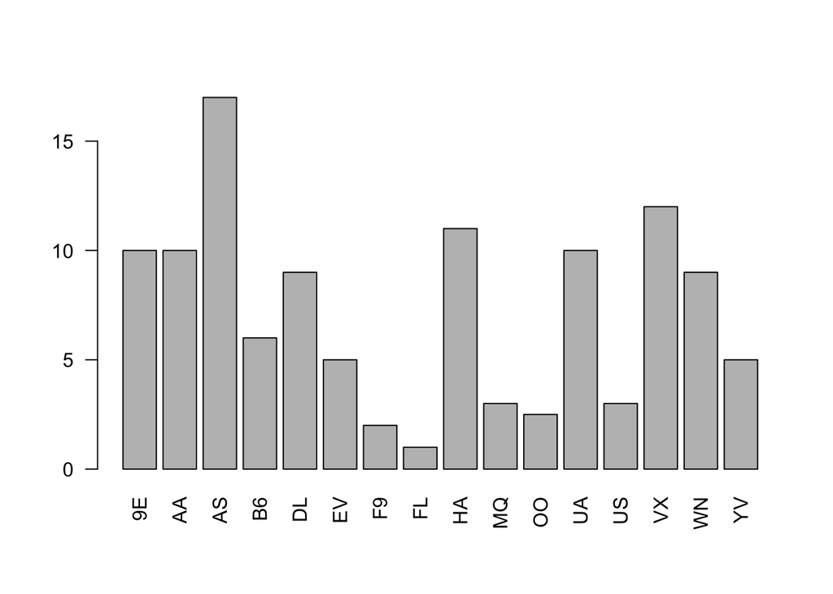

```r
barplot(airgain_per_airline_median, las = 2)
```

Evaluating both the mean and the median, the airline that has the best airgain is AS, meanwhile the worse job is from FL. Althought the worse mean is from F9, FL has the 2nd worse mean, and the worst median, probably indicating that they constantly do a worse job.

That’s it. Once you are done, make sure everything works and knits well and then you can uplaod the RMD flile and the html output to Canvas.

> Note that I encourage students to collaborate in doing HWs. If you work with someone then please acknowledge that person in your submission. Each student needs to submit his/her file and must have a full understanding of what you are submitting.

**Have Fun!**

Sanjeev